# Project: Investigate a Dataset - [European Soccer Database]

- Introduction
- Data Wrangling
- Exploratory Data Analysis
- Conclusions

## Introduction

### Dataset Description

**About the data:** The European Soccer Database sourced from Kaggle contains data on *over 25,000* matches played across **11** European countries/leagues between **2008 - 2016**. It also contains data on *over 10,000* players and about *300* teams.

### Question(s) for Analysis

1. What teams in the England Premier League improved the most over the time period?
2. What team attributes lead to the most victories?
3. Is there really such a thing as home advantage (do teams do better when they play at home)?
4. Who is the highest rated player?
5. What attributes affect player's rating?

```python
# import statements for all packages used
import numpy as np
import pandas as pd
import matplotlib.pyplot as plt
import seaborn as sns
import os
import zipfile
from sqlalchemy import create_engine, inspect
```

## Data Wrangling

> **Tip**: In this section of the report, you will load in the data, check for cleanliness, and then trim and clean your dataset for analysis. Make sure that you **document your data cleaning steps in mark-down cells precisely and justify your cleaning decisions.**

### General Properties

> **Tip**: You should *not* perform too many operations in each cell. Create cells freely to explore your data. One option that you can take with this project is to do a lot of explorations in an initial notebook. These don't have to be organized, but make sure you use enough comments to understand the purpose of each code cell. Then, after you're done with your analysis, create a duplicate notebook where you will trim the excess and organize your steps so that you have a flowing, cohesive report.

```python
if os.path.isdir('database') == False:
    with zipfile.ZipFile('database.sqlite.zip', 'r') as zipped_file:
        zipped_file.extractall("database")

# create database engine
engine = create_engine('sqlite:///database/database.sqlite')
```

```python
# print table names
inspect(engine).get_table_names()
```

```
['Country',
 'League',
 'Match',
 'Player',
 'Player_Attributes',
 'Team',
 'Team_Attributes',
 'sqlite_sequence']
```

```python
# Load each table and print out a few lines to inspect content
pd.read_sql("Country", engine)
```

|  | id | name |
| --- | --- | --- |
| 0 | 1 | Belgium |
| 1 | 1729 | England |
| 2 | 4769 | France |
| 3 | 7809 | Germany |
| 4 | 10257 | Italy |
| 5 | 13274 | Netherlands |
| 6 | 15722 | Poland |
| 7 | 17642 | Portugal |
| 8 | 19694 | Scotland |
| 9 | 21518 | Spain |
| 10 | 24558 | Switzerland |

```python
# inspect tables
pd.read_sql("Match", engine).shape
```

```
(25979, 115)
```

```python
# I chose to use data for the England Premier League matches because it is one of the top 3 leagues when considering the
#   total number of matches played in each league

total_matches_per_league = pd.read_sql("""SELECT l.name AS league,
                                                 COUNT(m.league_id) AS total_matches
                                          FROM League l
                                          LEFT JOIN Match m
                                          ON l.id = m.league_id
                                          GROUP BY league
                                          ORDER BY total_matches DESC""", engine)
total_matches_per_league.head()
```

|  | league | total_matches |
| --- | --- | --- |
| 0 | England Premier League | 3040 |
| 1 | France Ligue 1 | 3040 |
| 2 | Spain LIGA BBVA | 3040 |
| 3 | Italy Serie A | 3017 |
| 4 | Germany 1. Bundesliga | 2448 |

```python
# create a dataframe 'matches' containing data needed for this analysis using SQL queries

# I have created this dataframe using SQL joins to extract only the required data and columns from the Match, Team, Country and,
#   League tables.

# The last two columns indicate whether a team (home or away) won, lost or tied in the matches played.
# Wins are labeled 1, losses are labeled 0 and ties/draws are labeled 0.5. I used numeric labels in order to be able to easily
# aggregate the outcome in the EDA stage.

matches = pd.read_sql("""SELECT match_api_id AS match_id,
                                c.name AS country,
                                l.name AS league,
                                season, stage, date,
                                t1.team_long_name AS home_team,
                                t2.team_long_name AS away_team,
                                home_team_goal, away_team_goal,
                                CASE WHEN home_team_goal > away_team_goal THEN 1
                                     WHEN home_team_goal < away_team_goal THEN 0
                                     ELSE 0.5
                                     END AS home_outcome,
                                CASE WHEN away_team_goal > home_team_goal THEN 1
                                     WHEN away_team_goal < home_team_goal THEN 0
                                     ELSE 0.5
                                     END AS away_outcome,
                                CASE WHEN home_team_goal > away_team_goal THEN 'Home Wins'
                                     WHEN home_team_goal < away_team_goal THEN 'Away Wins'
                                     ELSE 'Draw'
                                     END AS outcome_label
                         FROM Match m
                         LEFT JOIN Team t1
                             ON t1.team_api_id = m.home_team_api_id
                         LEFT JOIN Team t2
                             ON t2.team_api_id = m.away_team_api_id
                         JOIN Country c
                             ON c.id = m.country_id
                         JOIN League l
                             ON l.id = m.league_id""", engine)
matches.head()
```

|  | match_id | country | league | season | stage | date | home_team | away_team | home_team_goal | away_team_goal | home_outcome | away_outcome | outcome_label |
| --- | --- | --- | --- | --- | --- | --- | --- | --- | --- | --- | --- | --- | --- |
| 0 | 492473 | Belgium | Belgium Jupiler League | 2008/2009 | 1 | 2008-08-17 00:00:00 | KRC Genk | Beerschot AC | 1 | 1 | 0.5 | 0.5 | Draw |
| 1 | 492474 | Belgium | Belgium Jupiler League | 2008/2009 | 1 | 2008-08-16 00:00:00 | SV Zulte-Waregem | Sporting Lokeren | 0 | 0 | 0.5 | 0.5 | Draw |
| 2 | 492475 | Belgium | Belgium Jupiler League | 2008/2009 | 1 | 2008-08-16 00:00:00 | KSV Cercle Brugge | RSC Anderlecht | 0 | 3 | 0.0 | 1.0 | Away Wins |
| 3 | 492476 | Belgium | Belgium Jupiler League | 2008/2009 | 1 | 2008-08-17 00:00:00 | KAA Gent | RAEC Mons | 5 | 0 | 1.0 | 0.0 | Home Wins |
| 4 | 492477 | Belgium | Belgium Jupiler League | 2008/2009 | 1 | 2008-08-16 00:00:00 | FCV Dender EH | Standard de Liège | 1 | 3 | 0.0 | 1.0 | Away Wins |

```python
# create a dataframe 'team_attributes' containing data needed for this project using SQL queries and joins

# I have created this dataframe using SQL joins to extract only the required data and columns from the Team and Team_Attributes
#   tables.

team_attributes = pd.read_sql("""SELECT t.team_api_id AS team_id,
                                        t.team_long_name AS team_name,
                                        date,
                                        buildUpPlaySpeed AS play_speed,
                                        buildUpPlaySpeedClass AS play_speed_class,
                                        buildUpPlayDribbling AS bup_dribbling,
                                        buildUpPlayDribblingClass AS bup_dribbling_class,
                                        buildUpPlayPassing AS bup_passing,
                                        buildUpPlayPassingClass AS bup_passing_class,
                                        buildUpPlayPositioningClass AS bup_positioning_class,
                                        chanceCreationPassing AS cc_passing,
                                        chanceCreationPassingClass AS cc_passing_class,
                                        chanceCreationCrossing AS cc_crossing,
                                        chanceCreationCrossingClass AS cc_crossing_class,
                                        chanceCreationShooting AS cc_shooting,
                                        chanceCreationShootingClass AS cc_shooting_class,
                                        chanceCreationPositioningClass AS cc_positioning_class,
                                        defencePressure AS def_pressure,
                                        defencePressureClass AS def_pressure_class,
                                        defenceAggression AS def_aggression,
                                        defenceAggressionClass AS def_aggression_class,
                                        defenceTeamWidth AS def_team_width,
                                        defenceTeamWidthClass AS def_team_width_class,
                                        defenceDefenderLineClass AS defd_line_class
                                FROM Team t
                                JOIN Team_Attributes ta
                                USING(team_api_id)""", engine)
team_attributes.head()
```

|  | team_id | team_name | date | play_speed | play_speed_class | bup_dribbling | bup_dribbling_class | bup_passing | bup_passing_class | bup_positioning_class | ... | cc_shooting | cc_shooting_class | cc_positioning_class | def_pressure | def_pressure_class | def_aggression | def_aggression_class | def_team_width | def_team_width_class | defd_line_class |
| --- | --- | --- | --- | --- | --- | --- | --- | --- | --- | --- | --- | --- | --- | --- | --- | --- | --- | --- | --- | --- | --- |
| 0 | 9930 | FC Aarau | 2010-02-22 00:00:00 | 60 | Balanced | NaN | Little | 50 | Mixed | Organised | ... | 55 | Normal | Organised | 50 | Medium | 55 | Press | 45 | Normal | Cover |
| 1 | 9930 | FC Aarau | 2014-09-19 00:00:00 | 52 | Balanced | 48.0 | Normal | 56 | Mixed | Organised | ... | 64 | Normal | Organised | 47 | Medium | 44 | Press | 54 | Normal | Cover |
| 2 | 9930 | FC Aarau | 2015-09-10 00:00:00 | 47 | Balanced | 41.0 | Normal | 54 | Mixed | Organised | ... | 64 | Normal | Organised | 47 | Medium | 44 | Press | 54 | Normal | Cover |
| 3 | 8485 | Aberdeen | 2010-02-22 00:00:00 | 70 | Fast | NaN | Little | 70 | Long | Organised | ... | 70 | Lots | Organised | 60 | Medium | 70 | Double | 70 | Wide | Cover |
| 4 | 8485 | Aberdeen | 2011-02-22 00:00:00 | 47 | Balanced | NaN | Little | 52 | Mixed | Organised | ... | 52 | Normal | Organised | 47 | Medium | 47 | Press | 52 | Normal | Cover |

5 rows × 24 columns

```python
players = pd.read_sql("""SELECT *
                         FROM Player
                         JOIN Player_Attributes
                         USING(player_api_id)""", engine)
players.head()
```

|  | id | player_api_id | player_name | player_fifa_api_id | birthday | height | weight | id | player_fifa_api_id | date | ... | vision | penalties | marking | standing_tackle | sliding_tackle | gk_diving | gk_handling | gk_kicking | gk_positioning | gk_reflexes |
| --- | --- | --- | --- | --- | --- | --- | --- | --- | --- | --- | --- | --- | --- | --- | --- | --- | --- | --- | --- | --- | --- |
| 0 | 1 | 505942 | Aaron Appindangoye | 218353 | 1992-02-29 00:00:00 | 182.88 | 187 | 1 | 218353 | 2016-02-18 00:00:00 | ... | 54.0 | 48.0 | 65.0 | 69.0 | 69.0 | 6.0 | 11.0 | 10.0 | 8.0 | 8.0 |
| 1 | 1 | 505942 | Aaron Appindangoye | 218353 | 1992-02-29 00:00:00 | 182.88 | 187 | 2 | 218353 | 2015-11-19 00:00:00 | ... | 54.0 | 48.0 | 65.0 | 69.0 | 69.0 | 6.0 | 11.0 | 10.0 | 8.0 | 8.0 |
| 2 | 1 | 505942 | Aaron Appindangoye | 218353 | 1992-02-29 00:00:00 | 182.88 | 187 | 3 | 218353 | 2015-09-21 00:00:00 | ... | 54.0 | 48.0 | 65.0 | 66.0 | 69.0 | 6.0 | 11.0 | 10.0 | 8.0 | 8.0 |
| 3 | 1 | 505942 | Aaron Appindangoye | 218353 | 1992-02-29 00:00:00 | 182.88 | 187 | 4 | 218353 | 2015-03-20 00:00:00 | ... | 53.0 | 47.0 | 62.0 | 63.0 | 66.0 | 5.0 | 10.0 | 9.0 | 7.0 | 7.0 |
| 4 | 1 | 505942 | Aaron Appindangoye | 218353 | 1992-02-29 00:00:00 | 182.88 | 187 | 5 | 218353 | 2007-02-22 00:00:00 | ... | 53.0 | 47.0 | 62.0 | 63.0 | 66.0 | 5.0 | 10.0 | 9.0 | 7.0 | 7.0 |

5 rows × 48 columns

```python
def inspect_data(table):
    inspection = {}
    inspection["duplicates"] = table.duplicated().sum()
    inspection["shape"] = table.shape
    table.info()
    return inspection
```

```python
# Perform operations to inspect matches data
#   types and look for instances of missing or possibly errant data.
inspect_data(matches)
```

```
<class 'pandas.core.frame.DataFrame'>
RangeIndex: 25979 entries, 0 to 25978
Data columns (total 13 columns):
 #   Column          Non-Null Count  Dtype
---  ------          --------------  -----
 0   match_id        25979 non-null  int64
 1   country         25979 non-null  object
 2   league          25979 non-null  object
 3   season          25979 non-null  object
 4   stage           25979 non-null  int64
 5   date            25979 non-null  object
 6   home_team       25979 non-null  object
 7   away_team       25979 non-null  object
 8   home_team_goal  25979 non-null  int64
 9   away_team_goal  25979 non-null  int64
 10  home_outcome    25979 non-null  float64
 11  away_outcome    25979 non-null  float64
 12  outcome_label   25979 non-null  object
dtypes: float64(2), int64(4), object(7)
memory usage: 2.6+ MB
```

```
{'duplicates': 0, 'shape': (25979, 13)}
```

```python
# Perform operations to inspect team attributes data
#   types and look for instances of missing or possibly errant data.

inspect_data(team_attributes)
```

```
<class 'pandas.core.frame.DataFrame'>
RangeIndex: 1458 entries, 0 to 1457
Data columns (total 24 columns):
 #   Column                 Non-Null Count  Dtype
---  ------                 --------------  -----
 0   team_id                1458 non-null   int64
 1   team_name              1458 non-null   object
 2   date                   1458 non-null   object
 3   play_speed             1458 non-null   int64
 4   play_speed_class       1458 non-null   object
 5   bup_dribbling          489 non-null    float64
 6   bup_dribbling_class    1458 non-null   object
 7   bup_passing            1458 non-null   int64
 8   bup_passing_class      1458 non-null   object
 9   bup_positioning_class  1458 non-null   object
```

[output cut: 16 more lines]

```
{'duplicates': 1, 'shape': (1458, 24)}
```

```python
# Perform operations to inspect players data
#   types and look for instances of missing or possibly errant data.

inspect_data(players)
```

```
<class 'pandas.core.frame.DataFrame'>
RangeIndex: 183978 entries, 0 to 183977
Data columns (total 48 columns):
 #   Column               Non-Null Count   Dtype
---  ------               --------------   -----
 0   id                   183978 non-null  int64
 1   player_api_id        183978 non-null  int64
 2   player_name          183978 non-null  object
 3   player_fifa_api_id   183978 non-null  int64
 4   birthday             183978 non-null  object
 5   height               183978 non-null  float64
 6   weight               183978 non-null  int64
 7   id                   183978 non-null  int64
 8   player_fifa_api_id   183978 non-null  int64
 9   date                 183978 non-null  object
```

[output cut: 40 more lines]

```
{'duplicates': 0, 'shape': (183978, 48)}
```

### Data Cleaning

**Observations**:

> The **matches** table is in a pretty good shape - it has no missing values and no duplicates, the only change I will be making to the dataframe will be changing the data type of the *date* column to datetime.

> The **team_attributes** table on the other hand has a duplicate row, the *bup_dribbling* column has a lot of missing values and the *date* column's data type is a string. The duplicate row will be removed, missing values will be filled and the date will be converted to datetime format.

> The **players** table has no duplicate row but has missing values for some values. I will be dropping all NaNs rows from this dataframe as well as columns that are not relevant to my analysis.

```python
# changing the data type of the date column to datetime in the matches table
matches["date"] = pd.to_datetime(matches["date"])
matches.head()
```

|  | match_id | country | league | season | stage | date | home_team | away_team | home_team_goal | away_team_goal | home_outcome | away_outcome | outcome_label |
| --- | --- | --- | --- | --- | --- | --- | --- | --- | --- | --- | --- | --- | --- |
| 0 | 492473 | Belgium | Belgium Jupiler League | 2008/2009 | 1 | 2008-08-17 | KRC Genk | Beerschot AC | 1 | 1 | 0.5 | 0.5 | Draw |
| 1 | 492474 | Belgium | Belgium Jupiler League | 2008/2009 | 1 | 2008-08-16 | SV Zulte-Waregem | Sporting Lokeren | 0 | 0 | 0.5 | 0.5 | Draw |
| 2 | 492475 | Belgium | Belgium Jupiler League | 2008/2009 | 1 | 2008-08-16 | KSV Cercle Brugge | RSC Anderlecht | 0 | 3 | 0.0 | 1.0 | Away Wins |
| 3 | 492476 | Belgium | Belgium Jupiler League | 2008/2009 | 1 | 2008-08-17 | KAA Gent | RAEC Mons | 5 | 0 | 1.0 | 0.0 | Home Wins |
| 4 | 492477 | Belgium | Belgium Jupiler League | 2008/2009 | 1 | 2008-08-16 | FCV Dender EH | Standard de Liège | 1 | 3 | 0.0 | 1.0 | Away Wins |

```python
# confirm change
matches.dtypes
```

```
match_id                   int64
country                   object
league                    object
season                    object
stage                      int64
date              datetime64[ns]
home_team                 object
away_team                 object
home_team_goal             int64
away_team_goal             int64
home_outcome             float64
away_outcome             float64
outcome_label             object
dtype: object
```

```python
# drop duplicate row in the team_attributes table
team_attributes.drop_duplicates(inplace=True)

# confirm that there is no more duplicate observation (result should be 0)
print(team_attributes.duplicated().sum())

# the number of rows should be 1 less - i.e., 1457
team_attributes.shape
```

```
0
```

```
(1457, 24)
```

```python
# the next step is to fill out missing data in the team_attributes table
# let's inspect the data first
team_attributes.describe()
```

|  | team_id | play_speed | bup_dribbling | bup_passing | cc_passing | cc_crossing | cc_shooting | def_pressure | def_aggression | def_team_width |
| --- | --- | --- | --- | --- | --- | --- | --- | --- | --- | --- |
| count | 1457.000000 | 1457.000000 | 488.000000 | 1457.000000 | 1457.000000 | 1457.000000 | 1457.000000 | 1457.000000 | 1457.000000 | 1457.000000 |
| mean | 9995.726836 | 52.463967 | 48.604508 | 48.489362 | 52.166781 | 53.734386 | 53.971860 | 46.017845 | 49.253946 | 52.187371 |
| std | 13269.424362 | 11.549653 | 9.688015 | 10.899771 | 10.364195 | 11.090171 | 10.330588 | 10.230702 | 9.740734 | 9.577828 |
| min | 1601.000000 | 20.000000 | 24.000000 | 20.000000 | 21.000000 | 20.000000 | 22.000000 | 23.000000 | 24.000000 | 29.000000 |
| 25% | 8457.000000 | 45.000000 | 42.000000 | 40.000000 | 46.000000 | 47.000000 | 48.000000 | 39.000000 | 44.000000 | 47.000000 |
| 50% | 8674.000000 | 52.000000 | 49.000000 | 50.000000 | 52.000000 | 53.000000 | 53.000000 | 45.000000 | 48.000000 | 52.000000 |
| 75% | 9904.000000 | 62.000000 | 55.000000 | 55.000000 | 59.000000 | 62.000000 | 61.000000 | 51.000000 | 55.000000 | 58.000000 |
| max | 274581.000000 | 80.000000 | 77.000000 | 80.000000 | 80.000000 | 80.000000 | 80.000000 | 72.000000 | 72.000000 | 73.000000 |

```python
# look at null data
nulls = team_attributes[team_attributes["bup_dribbling"].isnull()]
nulls.head()
```

|  | team_id | team_name | date | play_speed | play_speed_class | bup_dribbling | bup_dribbling_class | bup_passing | bup_passing_class | bup_positioning_class | ... | cc_shooting | cc_shooting_class | cc_positioning_class | def_pressure | def_pressure_class | def_aggression | def_aggression_class | def_team_width | def_team_width_class | defd_line_class |
| --- | --- | --- | --- | --- | --- | --- | --- | --- | --- | --- | --- | --- | --- | --- | --- | --- | --- | --- | --- | --- | --- |
| 0 | 9930 | FC Aarau | 2010-02-22 00:00:00 | 60 | Balanced | NaN | Little | 50 | Mixed | Organised | ... | 55 | Normal | Organised | 50 | Medium | 55 | Press | 45 | Normal | Cover |
| 3 | 8485 | Aberdeen | 2010-02-22 00:00:00 | 70 | Fast | NaN | Little | 70 | Long | Organised | ... | 70 | Lots | Organised | 60 | Medium | 70 | Double | 70 | Wide | Cover |
| 4 | 8485 | Aberdeen | 2011-02-22 00:00:00 | 47 | Balanced | NaN | Little | 52 | Mixed | Organised | ... | 52 | Normal | Organised | 47 | Medium | 47 | Press | 52 | Normal | Cover |
| 5 | 8485 | Aberdeen | 2012-02-22 00:00:00 | 58 | Balanced | NaN | Little | 62 | Mixed | Organised | ... | 55 | Normal | Organised | 40 | Medium | 40 | Press | 60 | Normal | Cover |
| 6 | 8485 | Aberdeen | 2013-09-20 00:00:00 | 62 | Balanced | NaN | Little | 45 | Mixed | Organised | ... | 55 | Normal | Organised | 42 | Medium | 42 | Press | 60 | Normal | Cover |

5 rows × 24 columns

```python
# further inspection of null data shows that all null values are of the bup_dribbling_class - "Little"
team_attributes[team_attributes["bup_dribbling"].isnull()].groupby("bup_dribbling_class")[["bup_dribbling", "bup_passing"]] \
                                                .count()
```

| bup_dribbling_class | bup_dribbling | bup_passing |
| --- | --- | --- |
| Little | 0 | 969 |

```python
# It would be best to fill the NaN values with the mean of the "Little" Class. Let's get this data
means_bup_dribbling_class = team_attributes.groupby("bup_dribbling_class")["bup_dribbling"].mean()
means_bup_dribbling_class
```

```
bup_dribbling_class
Little    30.485714
Lots      69.809524
Normal    49.041667
Name: bup_dribbling, dtype: float64
```

```python
# the mean of the "Little" class
little_mean = round(means_bup_dribbling_class[0])
little_mean
```

```
30
```

```python
# use the value of little_mean to fill missing values
team_attributes["bup_dribbling"] = team_attributes["bup_dribbling"].fillna(little_mean)
team_attributes.head()
```

|  | team_id | team_name | date | play_speed | play_speed_class | bup_dribbling | bup_dribbling_class | bup_passing | bup_passing_class | bup_positioning_class | ... | cc_shooting | cc_shooting_class | cc_positioning_class | def_pressure | def_pressure_class | def_aggression | def_aggression_class | def_team_width | def_team_width_class | defd_line_class |
| --- | --- | --- | --- | --- | --- | --- | --- | --- | --- | --- | --- | --- | --- | --- | --- | --- | --- | --- | --- | --- | --- |
| 0 | 9930 | FC Aarau | 2010-02-22 00:00:00 | 60 | Balanced | 30.0 | Little | 50 | Mixed | Organised | ... | 55 | Normal | Organised | 50 | Medium | 55 | Press | 45 | Normal | Cover |
| 1 | 9930 | FC Aarau | 2014-09-19 00:00:00 | 52 | Balanced | 48.0 | Normal | 56 | Mixed | Organised | ... | 64 | Normal | Organised | 47 | Medium | 44 | Press | 54 | Normal | Cover |
| 2 | 9930 | FC Aarau | 2015-09-10 00:00:00 | 47 | Balanced | 41.0 | Normal | 54 | Mixed | Organised | ... | 64 | Normal | Organised | 47 | Medium | 44 | Press | 54 | Normal | Cover |
| 3 | 8485 | Aberdeen | 2010-02-22 00:00:00 | 70 | Fast | 30.0 | Little | 70 | Long | Organised | ... | 70 | Lots | Organised | 60 | Medium | 70 | Double | 70 | Wide | Cover |
| 4 | 8485 | Aberdeen | 2011-02-22 00:00:00 | 47 | Balanced | 30.0 | Little | 52 | Mixed | Organised | ... | 52 | Normal | Organised | 47 | Medium | 47 | Press | 52 | Normal | Cover |

5 rows × 24 columns

```python
# the last step is to change the data type of the date column to datetime in the team_attributes table

team_attributes["date"] = pd.to_datetime(team_attributes["date"])
team_attributes.head()
```

|  | team_id | team_name | date | play_speed | play_speed_class | bup_dribbling | bup_dribbling_class | bup_passing | bup_passing_class | bup_positioning_class | ... | cc_shooting | cc_shooting_class | cc_positioning_class | def_pressure | def_pressure_class | def_aggression | def_aggression_class | def_team_width | def_team_width_class | defd_line_class |
| --- | --- | --- | --- | --- | --- | --- | --- | --- | --- | --- | --- | --- | --- | --- | --- | --- | --- | --- | --- | --- | --- |
| 0 | 9930 | FC Aarau | 2010-02-22 | 60 | Balanced | 30.0 | Little | 50 | Mixed | Organised | ... | 55 | Normal | Organised | 50 | Medium | 55 | Press | 45 | Normal | Cover |
| 1 | 9930 | FC Aarau | 2014-09-19 | 52 | Balanced | 48.0 | Normal | 56 | Mixed | Organised | ... | 64 | Normal | Organised | 47 | Medium | 44 | Press | 54 | Normal | Cover |
| 2 | 9930 | FC Aarau | 2015-09-10 | 47 | Balanced | 41.0 | Normal | 54 | Mixed | Organised | ... | 64 | Normal | Organised | 47 | Medium | 44 | Press | 54 | Normal | Cover |
| 3 | 8485 | Aberdeen | 2010-02-22 | 70 | Fast | 30.0 | Little | 70 | Long | Organised | ... | 70 | Lots | Organised | 60 | Medium | 70 | Double | 70 | Wide | Cover |
| 4 | 8485 | Aberdeen | 2011-02-22 | 47 | Balanced | 30.0 | Little | 52 | Mixed | Organised | ... | 52 | Normal | Organised | 47 | Medium | 47 | Press | 52 | Normal | Cover |

5 rows × 24 columns

```python
# confirm that they are no more missing values and that the data type of date is datetime
team_attributes.info()
```

```
<class 'pandas.core.frame.DataFrame'>
Int64Index: 1457 entries, 0 to 1457
Data columns (total 24 columns):
 #   Column                 Non-Null Count  Dtype
---  ------                 --------------  -----
 0   team_id                1457 non-null   int64
 1   team_name              1457 non-null   object
 2   date                   1457 non-null   datetime64[ns]
 3   play_speed             1457 non-null   int64
 4   play_speed_class       1457 non-null   object
 5   bup_dribbling          1457 non-null   float64
 6   bup_dribbling_class    1457 non-null   object
 7   bup_passing            1457 non-null   int64
 8   bup_passing_class      1457 non-null   object
 9   bup_positioning_class  1457 non-null   object
```

[output cut: 16 more lines]

```python
# drop NaN rows in the players table
players = players.dropna()
players.reset_index(drop=True, inplace=True)

# drop columns that are not needed
players.drop(columns=['id', 'player_fifa_api_id', 'birthday', 'id', 'player_fifa_api_id', 'date', 'height', 'weight'], inplace=True)

# confirm changes
inspect_data(players)
```

```
<class 'pandas.core.frame.DataFrame'>
RangeIndex: 180354 entries, 0 to 180353
Data columns (total 40 columns):
 #   Column               Non-Null Count   Dtype
---  ------               --------------   -----
 0   player_api_id        180354 non-null  int64
 1   player_name          180354 non-null  object
 2   overall_rating       180354 non-null  float64
 3   potential            180354 non-null  float64
 4   preferred_foot       180354 non-null  object
 5   attacking_work_rate  180354 non-null  object
 6   defensive_work_rate  180354 non-null  object
 7   crossing             180354 non-null  float64
 8   finishing            180354 non-null  float64
 9   heading_accuracy     180354 non-null  float64
```

[output cut: 32 more lines]

```
{'duplicates': 44004, 'shape': (180354, 40)}
```

## Exploratory Data Analysis

> **Tip**: Now that you've trimmed and cleaned your data, you're ready to move on to exploration. **Compute statistics** and **create visualizations** with the goal of addressing the research questions that you posed in the Introduction section. You should compute the relevant statistics throughout the analysis when an inference is made about the data. Note that at least two or more kinds of plots should be created as part of the exploration, and you must compare and show trends in the varied visualizations.

> **Tip**: - Investigate the stated question(s) from multiple angles. It is recommended that you be systematic with your approach. Look at one variable at a time, and then follow it up by looking at relationships between variables. You should explore at least three variables in relation to the primary question. This can be an exploratory relationship between three variables of interest, or looking at how two independent variables relate to a single dependent variable of interest. Lastly, you should perform both single-variable (1d) and multiple-variable (2d) explorations.

### Research Question 1: What teams improved the most over the time period?

```python
# this dataframe contains data on teams and the outcome of their home matches grouped by seasons.

# I modified the SQL Query from the matches table to get this result
# The CASE Statement I used in the matches table to indicate whether a team won, lost or tied a match (the outcomes) is also
#   used here to compute the percentage win of each team per season

# I'm considering only matches played in the England Premier League

home_team_matches = pd.read_sql("""SELECT season,
                                          t1.team_api_id AS team_id,
                                          t1.team_long_name AS team,
                                          t1.team_short_name,
                                          COUNT(match_api_id) AS total_home_matches,
                                          SUM(CASE WHEN home_team_goal > away_team_goal THEN 1
                                                   WHEN home_team_goal < away_team_goal THEN 0
                                                   ELSE 0.5
                                                   END) * 100 / COUNT(match_api_id) AS home_percentage_win
                         FROM Match m
                         LEFT JOIN Team t1
                             ON t1.team_api_id = m.home_team_api_id
                         LEFT JOIN Team t2
                             ON t2.team_api_id = m.away_team_api_id
                         JOIN Country c
                             ON c.id = m.country_id
                         JOIN League l
                             ON l.id = m.league_id
                         WHERE l.name = 'England Premier League'
                         GROUP BY season, team_id, team
                         ORDER BY season, total_home_matches""", engine)
home_team_matches.head()
```

|  | season | team_id | team | team_short_name | total_home_matches | home_percentage_win |
| --- | --- | --- | --- | --- | --- | --- |
| 0 | 2008/2009 | 8455 | Chelsea | CHE | 19 | 73.684211 |
| 1 | 2008/2009 | 8456 | Manchester City | MCI | 19 | 68.000000 |
| 2 | 2008/2009 | 8462 | Portsmouth | POR | 19 | 50.000000 |
| 3 | 2008/2009 | 8472 | Sunderland | SUN | 19 | 39.473684 |
| 4 | 2008/2009 | 8528 | Wigan Athletic | WIG | 19 | 55.263158 |

```python
# this dataframe contains data on teams and the outcome of their away matches grouped by seasons.

# I modified the SQL Query from the matches table to get this result
# The CASE Statement I used in the matches table to indicate whether a team won, lost or tied a match (the outcomes) is also
#   used here to compute the percentage win of each team per season

# I'm considering only matches played in the England Premier League

away_team_matches = pd.read_sql("""SELECT season,
                                          t2.team_api_id AS team_id,
                                          t2.team_long_name AS team,
                                          t2.team_short_name,
                                          COUNT(match_api_id) AS total_away_matches,
                                          SUM(CASE WHEN away_team_goal > home_team_goal THEN 1
                                                   WHEN away_team_goal < home_team_goal THEN 0
                                                   ELSE 0.5
                                                   END) * 100 / COUNT(match_api_id) AS away_percentage_win
                         FROM Match m
                         LEFT JOIN Team t1
                             ON t1.team_api_id = m.home_team_api_id
                         LEFT JOIN Team t2
                             ON t2.team_api_id = m.away_team_api_id
                         JOIN Country c
                             ON c.id = m.country_id
                         JOIN League l
                             ON l.id = m.league_id
                         WHERE l.name = 'England Premier League'
                         GROUP BY season, team_id, team
                         ORDER BY season, total_away_matches""", engine)
away_team_matches.head()
```

|  | season | team_id | team | team_short_name | total_away_matches | away_percentage_win |
| --- | --- | --- | --- | --- | --- | --- |
| 0 | 2008/2009 | 8455 | Chelsea | CHE | 19 | 78.947368 |
| 1 | 2008/2009 | 8456 | Manchester City | MCI | 19 | 23.684211 |
| 2 | 2008/2009 | 8462 | Portsmouth | POR | 19 | 31.578947 |
| 3 | 2008/2009 | 8472 | Sunderland | SUN | 19 | 31.578947 |
| 4 | 2008/2009 | 8528 | Wigan Athletic | WIG | 19 | 31.578947 |

```python
# inspect tables
print(home_team_matches.shape)
print(away_team_matches.shape)
print(home_team_matches.info())
print(away_team_matches.info())
```

```
(160, 6)
(160, 6)
<class 'pandas.core.frame.DataFrame'>
RangeIndex: 160 entries, 0 to 159
Data columns (total 6 columns):
 #   Column               Non-Null Count  Dtype
---  ------               --------------  -----
 0   season               160 non-null    object
 1   team_id              160 non-null    int64
 2   team                 160 non-null    object
 3   team_short_name      160 non-null    object
 4   total_home_matches   160 non-null    int64
 5   home_percentage_win  160 non-null    float64
dtypes: float64(1), int64(2), object(3)
memory usage: 7.6+ KB
None
<class 'pandas.core.frame.DataFrame'>
RangeIndex: 160 entries, 0 to 159
Data columns (total 6 columns):
 #   Column               Non-Null Count  Dtype
---  ------               --------------  -----
 0   season               160 non-null    object
 1   team_id              160 non-null    int64
 2   team                 160 non-null    object
 3   team_short_name      160 non-null    object
 4   total_away_matches   160 non-null    int64
 5   away_percentage_win  160 non-null    float64
dtypes: float64(1), int64(2), object(3)
memory usage: 7.6+ KB
None
```

```python
# merge tables
home_away_matches =  home_team_matches.merge(away_team_matches, on=["season", "team_id", "team", "team_short_name"])
print(home_away_matches.shape)
home_away_matches.head()
```

```
(160, 8)
```

|  | season | team_id | team | team_short_name | total_home_matches | home_percentage_win | total_away_matches | away_percentage_win |
| --- | --- | --- | --- | --- | --- | --- | --- | --- |
| 0 | 2008/2009 | 8455 | Chelsea | CHE | 19 | 73.684211 | 19 | 78.947368 |
| 1 | 2008/2009 | 8456 | Manchester City | MCI | 19 | 68.000000 | 19 | 23.684211 |
| 2 | 2008/2009 | 8462 | Portsmouth | POR | 19 | 50.000000 | 19 | 31.578947 |
| 3 | 2008/2009 | 8472 | Sunderland | SUN | 19 | 39.473684 | 19 | 31.578947 |
| 4 | 2008/2009 | 8528 | Wigan Athletic | WIG | 19 | 55.263158 | 19 | 31.578947 |

```python
# add a column that calculates total wins using the home_percentage_win and away_percentage win columns
home_away_matches["total_win"] = (home_away_matches["home_percentage_win"] + home_away_matches["away_percentage_win"]) / 2
home_away_matches.head()
```

|  | season | team_id | team | team_short_name | total_home_matches | home_percentage_win | total_away_matches | away_percentage_win | total_win |
| --- | --- | --- | --- | --- | --- | --- | --- | --- | --- |
| 0 | 2008/2009 | 8455 | Chelsea | CHE | 19 | 73.684211 | 19 | 78.947368 | 76.315789 |
| 1 | 2008/2009 | 8456 | Manchester City | MCI | 19 | 68.000000 | 19 | 23.684211 | 45.842105 |
| 2 | 2008/2009 | 8462 | Portsmouth | POR | 19 | 50.000000 | 19 | 31.578947 | 40.789474 |
| 3 | 2008/2009 | 8472 | Sunderland | SUN | 19 | 39.473684 | 19 | 31.578947 | 35.526316 |
| 4 | 2008/2009 | 8528 | Wigan Athletic | WIG | 19 | 55.263158 | 19 | 31.578947 | 43.421053 |

```python
# Get teams whose overall total_wins are above 50%

teams_total_wins = home_away_matches.groupby("team")[["total_win"]].mean().sort_values("total_win", ascending=False)
top_teams = teams_total_wins[teams_total_wins["total_win"] > 50]
top_teams
```

| team | total_win |
| --- | --- |
| Manchester United | 72.519737 |
| Chelsea | 69.407895 |
| Arsenal | 67.927632 |
| Manchester City | 67.572368 |
| Liverpool | 61.842105 |
| Tottenham Hotspur | 61.842105 |
| Leicester City | 57.894737 |
| Everton | 56.250000 |
| Southampton | 52.631579 |

```python
# Subset for top_teams
top_team_matches = home_away_matches[home_away_matches["team"].isin(top_teams.index)].reset_index(drop=True)
top_team_matches.head()
```

|  | season | team_id | team | team_short_name | total_home_matches | home_percentage_win | total_away_matches | away_percentage_win | total_win |
| --- | --- | --- | --- | --- | --- | --- | --- | --- | --- |
| 0 | 2008/2009 | 8455 | Chelsea | CHE | 19 | 73.684211 | 19 | 78.947368 | 76.315789 |
| 1 | 2008/2009 | 8456 | Manchester City | MCI | 19 | 68.000000 | 19 | 23.684211 | 45.842105 |
| 2 | 2008/2009 | 8586 | Tottenham Hotspur | TOT | 19 | 65.789474 | 19 | 31.578947 | 48.684211 |
| 3 | 2008/2009 | 8650 | Liverpool | LIV | 19 | 81.578947 | 19 | 78.947368 | 80.263158 |
| 4 | 2008/2009 | 8668 | Everton | EVE | 19 | 57.894737 | 19 | 63.157895 | 60.526316 |

```python
# create a pivot table with the values of interests, i.e., total wins

# this table summarizes the performance of top teams across all seasons
# from the pivot table, I found that two of the top teams did not play matches in most seasons, I have dropped these teams
to_plot = top_team_matches.pivot_table(values="total_win", columns="season", index="team").dropna()
to_plot.columns.name = None
to_plot
```

| team | 2008/2009 | 2009/2010 | 2010/2011 | 2011/2012 | 2012/2013 | 2013/2014 | 2014/2015 | 2015/2016 |
| --- | --- | --- | --- | --- | --- | --- | --- | --- |
| Arsenal | 68.421053 | 68.421053 | 64.473684 | 64.473684 | 68.421053 | 72.368421 | 69.736842 | 67.105263 |
| Chelsea | 76.315789 | 77.631579 | 65.789474 | 60.526316 | 69.736842 | 75.000000 | 80.263158 | 50.000000 |
| Everton | 60.526316 | 59.210526 | 53.947368 | 53.947368 | 61.842105 | 67.105263 | 46.052632 | 47.368421 |
| Liverpool | 80.263158 | 59.210526 | 53.947368 | 50.000000 | 59.210526 | 76.315789 | 57.894737 | 57.894737 |
| Manchester City | 45.842105 | 64.473684 | 65.789474 | 80.263158 | 72.368421 | 77.631579 | 72.368421 | 61.842105 |
| Manchester United | 81.578947 | 76.315789 | 75.000000 | 80.263158 | 80.157895 | 59.210526 | 65.789474 | 61.842105 |
| Tottenham Hotspur | 48.684211 | 64.473684 | 60.526316 | 64.473684 | 67.105263 | 63.157895 | 59.210526 | 67.105263 |

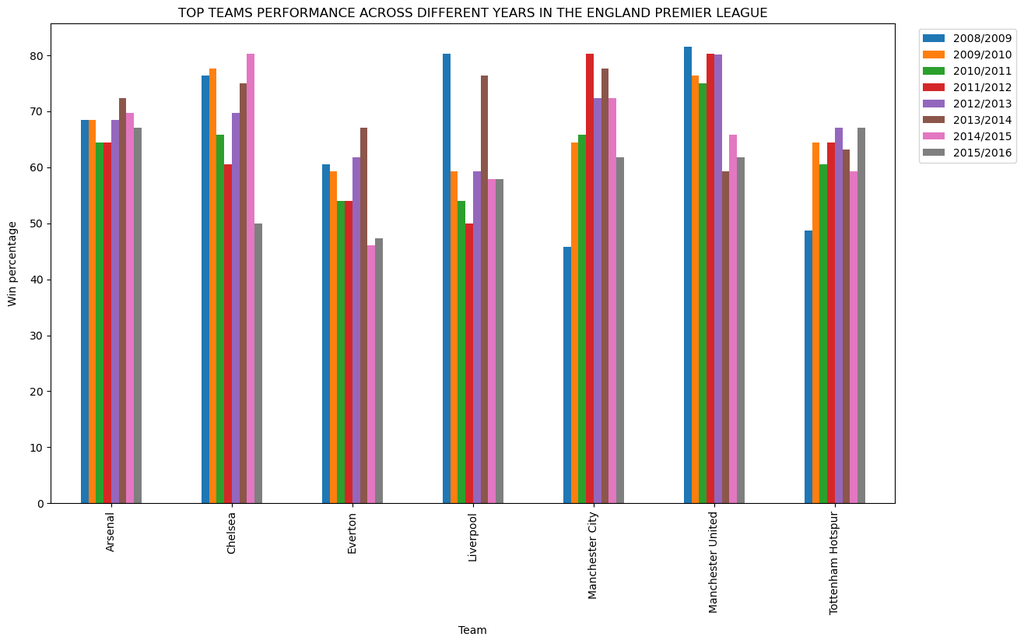

```python
# create visualization to show the performance of top teams
to_plot.plot(kind="bar", figsize=(14, 8))
plt.xlabel("Team", labelpad=10)
plt.ylabel("Win percentage", labelpad=10)
plt.title("TOP TEAMS PERFORMANCE ACROSS DIFFERENT YEARS IN THE ENGLAND PREMIER LEAGUE")
plt.legend(loc="upper right", bbox_to_anchor=(1.15, 1));
```

### Research Question 2: What team attributes lead to the most victories?

We would consider the team attributes for ONLY the top teams to answer this question.

```python
# subset of the team_attributes tables containing only attributes of top teams
top_team_attributes = team_attributes[team_attributes["team_name"].isin(to_plot.index)].reset_index(drop=True)
top_team_attributes.head()
```

|  | team_id | team_name | date | play_speed | play_speed_class | bup_dribbling | bup_dribbling_class | bup_passing | bup_passing_class | bup_positioning_class | ... | cc_shooting | cc_shooting_class | cc_positioning_class | def_pressure | def_pressure_class | def_aggression | def_aggression_class | def_team_width | def_team_width_class | defd_line_class |
| --- | --- | --- | --- | --- | --- | --- | --- | --- | --- | --- | --- | --- | --- | --- | --- | --- | --- | --- | --- | --- | --- |
| 0 | 9825 | Arsenal | 2010-02-22 | 66 | Balanced | 30.0 | Little | 30 | Short | Free Form | ... | 35 | Normal | Free Form | 30 | Deep | 40 | Press | 50 | Normal | Cover |
| 1 | 9825 | Arsenal | 2011-02-22 | 75 | Fast | 30.0 | Little | 40 | Mixed | Free Form | ... | 65 | Normal | Free Form | 50 | Medium | 40 | Press | 45 | Normal | Cover |
| 2 | 9825 | Arsenal | 2012-02-22 | 25 | Slow | 30.0 | Little | 32 | Short | Organised | ... | 30 | Little | Free Form | 57 | Medium | 57 | Press | 52 | Normal | Cover |
| 3 | 9825 | Arsenal | 2013-09-20 | 30 | Slow | 30.0 | Little | 29 | Short | Organised | ... | 39 | Normal | Free Form | 64 | Medium | 54 | Press | 52 | Normal | Cover |
| 4 | 9825 | Arsenal | 2014-09-19 | 59 | Balanced | 51.0 | Normal | 26 | Short | Organised | ... | 64 | Normal | Free Form | 51 | Medium | 44 | Press | 52 | Normal | Cover |

5 rows × 24 columns

```python
# extract year from date to get the year column and drop columns that are not needed for this analysis
top_team_attributes['year'] = top_team_attributes['date'].dt.year
top_team_attributes = top_team_attributes.drop(columns=['play_speed_class', 'bup_dribbling_class', 'bup_passing_class', \
                                                        'bup_positioning_class', 'cc_passing_class', 'cc_crossing_class', \
                                                        'cc_shooting_class', 'cc_positioning_class', 'def_pressure_class', \
                                                        'def_aggression_class', 'def_team_width_class', 'defd_line_class'])
```

```python
# inspect
top_team_attributes.head()
```

|  | team_id | team_name | date | play_speed | bup_dribbling | bup_passing | cc_passing | cc_crossing | cc_shooting | def_pressure | def_aggression | def_team_width | year |
| --- | --- | --- | --- | --- | --- | --- | --- | --- | --- | --- | --- | --- | --- |
| 0 | 9825 | Arsenal | 2010-02-22 | 66 | 30.0 | 30 | 30 | 45 | 35 | 30 | 40 | 50 | 2010 |
| 1 | 9825 | Arsenal | 2011-02-22 | 75 | 30.0 | 40 | 40 | 45 | 65 | 50 | 40 | 45 | 2011 |
| 2 | 9825 | Arsenal | 2012-02-22 | 25 | 30.0 | 32 | 41 | 34 | 30 | 57 | 57 | 52 | 2012 |
| 3 | 9825 | Arsenal | 2013-09-20 | 30 | 30.0 | 29 | 41 | 55 | 39 | 64 | 54 | 52 | 2013 |
| 4 | 9825 | Arsenal | 2014-09-19 | 59 | 51.0 | 26 | 28 | 55 | 64 | 51 | 44 | 52 | 2014 |

```python
# get the mean of all team attributes across different years. This data will be plotted
to_visualize = top_team_attributes.groupby("team_name")[["play_speed", "bup_dribbling", "bup_passing", "cc_passing", \
                                                       "cc_crossing", "cc_shooting", "def_pressure", "def_aggression", \
                                                       "def_team_width"]].mean()
to_visualize
```

| team_name | play_speed | bup_dribbling | bup_passing | cc_passing | cc_crossing | cc_shooting | def_pressure | def_aggression | def_team_width |
| --- | --- | --- | --- | --- | --- | --- | --- | --- | --- |
| Arsenal | 52.333333 | 37.000000 | 31.166667 | 34.666667 | 46.333333 | 46.500000 | 50.500000 | 46.500000 | 50.500000 |
| Chelsea | 61.666667 | 35.500000 | 45.000000 | 49.833333 | 55.166667 | 61.666667 | 40.833333 | 50.333333 | 44.833333 |
| Everton | 56.333333 | 33.166667 | 52.500000 | 48.166667 | 58.000000 | 49.833333 | 48.333333 | 57.500000 | 56.333333 |
| Liverpool | 57.666667 | 38.000000 | 44.333333 | 41.333333 | 47.833333 | 57.333333 | 51.000000 | 52.500000 | 56.000000 |
| Manchester City | 56.500000 | 31.666667 | 44.500000 | 45.666667 | 50.333333 | 52.833333 | 48.666667 | 52.500000 | 51.833333 |
| Manchester United | 51.833333 | 32.666667 | 45.833333 | 50.000000 | 63.166667 | 53.833333 | 45.000000 | 48.000000 | 54.833333 |
| Tottenham Hotspur | 50.666667 | 33.500000 | 46.000000 | 49.833333 | 59.333333 | 62.333333 | 51.166667 | 50.000000 | 55.000000 |

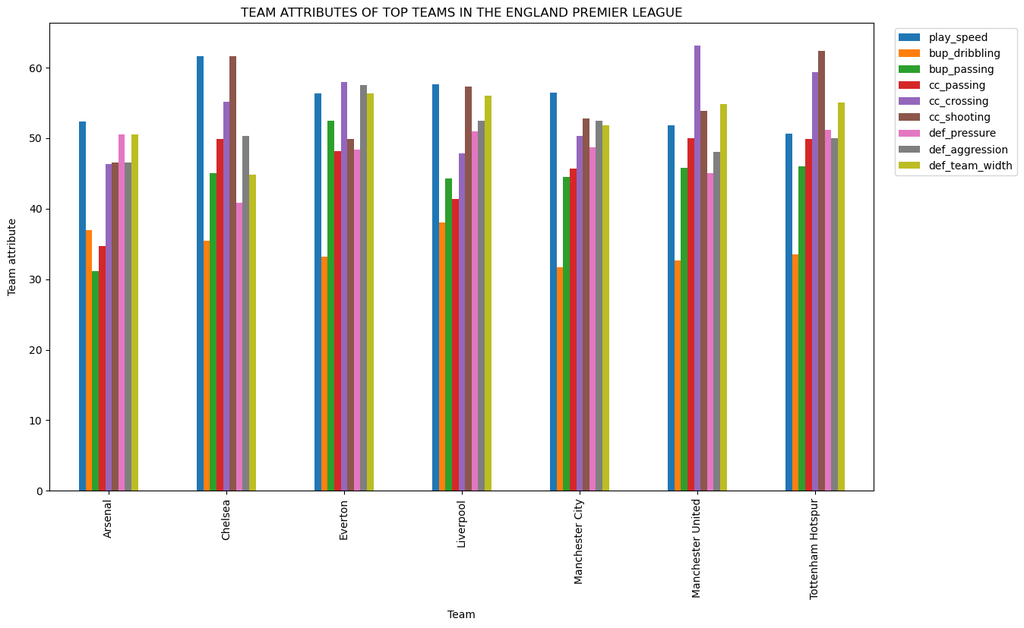

```python
# create visualization to show the attributes of top teams
to_visualize.plot(kind="bar", figsize=(14, 8))
plt.xlabel("Team", labelpad=10)
plt.ylabel("Team attribute", labelpad=10)
plt.title("TEAM ATTRIBUTES OF TOP TEAMS IN THE ENGLAND PREMIER LEAGUE")
plt.legend(loc="upper right", bbox_to_anchor=(1.18, 1));
```